# examples_0107

Simplify the following powers of $i$.

- $i^{18}=$
- $i^{20}=$
- $i^{47}=$
- $i^{60}=$
- $i^{85}=$

For any positive integer $n$, we can evaluate $i^n$ by determining the remainder when $n$ is divided by 4.

| Remainder of $n/4$ | $i^n$ |
| --- | --- |
| 0 | $1$ |
| 1 | $i$ |
| 2 | $-1$ |
| 3 | $-i$ |

In computer programming, the [modulo operator](https://en.wikipedia.org/wiki/Modulo) returns the remainder. This operation is used so frequently, that it is often abbreviated to a single symbol (for example, in Python, `5%2` represents the remainder when 5 is divided by 2.)

I will represent the remainders using the [Desmos](https://www.desmos.com/calculator) notation.

- $\mathrm{mod}(18,4)=2$ so $i^{18}=-1$
- $\mathrm{mod}(20,4)=0$ so $i^{20}=1$
- $\mathrm{mod}(47,4)=3$ so $i^{47}=-i$
- $\mathrm{mod}(60,4)=0$ so $i^{60}=1$
- $\mathrm{mod}(85,4)=1$ so $i^{85}=i$

To find the remainder using a scientific calculator, I would divide by 4, [floor](https://en.wikipedia.org/wiki/Floor_and_ceiling_functions) the result, multiply by 4, and subtract that amount from the original.

$$\mathrm{mod}(x,4)~=~x-4\cdot
\left\lfloor\frac{x}{4}\right\rfloor$$

Simplify the following powers of $i$.

- $i^{17}=$
- $i^{38}=$
- $i^{59}=$
- $i^{62}=$
- $i^{68}=$

For any positive integer $n$, we can evaluate $i^n$ by determining the remainder when $n$ is divided by 4.

| Remainder of $n/4$ | $i^n$ |
| --- | --- |
| 0 | $1$ |
| 1 | $i$ |
| 2 | $-1$ |
| 3 | $-i$ |

In computer programming, the [modulo operator](https://en.wikipedia.org/wiki/Modulo) returns the remainder. This operation is used so frequently, that it is often abbreviated to a single symbol (for example, in Python, `5%2` represents the remainder when 5 is divided by 2.)

I will represent the remainders using the [Desmos](https://www.desmos.com/calculator) notation.

- $\mathrm{mod}(17,4)=1$ so $i^{17}=i$
- $\mathrm{mod}(38,4)=2$ so $i^{38}=-1$
- $\mathrm{mod}(59,4)=3$ so $i^{59}=-i$
- $\mathrm{mod}(62,4)=2$ so $i^{62}=-1$
- $\mathrm{mod}(68,4)=0$ so $i^{68}=1$

To find the remainder using a scientific calculator, I would divide by 4, [floor](https://en.wikipedia.org/wiki/Floor_and_ceiling_functions) the result, multiply by 4, and subtract that amount from the original.

$$\mathrm{mod}(x,4)~=~x-4\cdot
\left\lfloor\frac{x}{4}\right\rfloor$$

Simplify the following powers of $i$.

- $i^{33}=$
- $i^{67}=$
- $i^{80}=$
- $i^{82}=$
- $i^{89}=$

For any positive integer $n$, we can evaluate $i^n$ by determining the remainder when $n$ is divided by 4.

| Remainder of $n/4$ | $i^n$ |
| --- | --- |
| 0 | $1$ |
| 1 | $i$ |
| 2 | $-1$ |
| 3 | $-i$ |

In computer programming, the [modulo operator](https://en.wikipedia.org/wiki/Modulo) returns the remainder. This operation is used so frequently, that it is often abbreviated to a single symbol (for example, in Python, `5%2` represents the remainder when 5 is divided by 2.)

I will represent the remainders using the [Desmos](https://www.desmos.com/calculator) notation.

- $\mathrm{mod}(33,4)=1$ so $i^{33}=i$
- $\mathrm{mod}(67,4)=3$ so $i^{67}=-i$
- $\mathrm{mod}(80,4)=0$ so $i^{80}=1$
- $\mathrm{mod}(82,4)=2$ so $i^{82}=-1$
- $\mathrm{mod}(89,4)=1$ so $i^{89}=i$

To find the remainder using a scientific calculator, I would divide by 4, [floor](https://en.wikipedia.org/wiki/Floor_and_ceiling_functions) the result, multiply by 4, and subtract that amount from the original.

$$\mathrm{mod}(x,4)~=~x-4\cdot
\left\lfloor\frac{x}{4}\right\rfloor$$

Simplify the following powers of $i$.

- $i^{19}=$
- $i^{50}=$
- $i^{60}=$
- $i^{61}=$
- $i^{80}=$

For any positive integer $n$, we can evaluate $i^n$ by determining the remainder when $n$ is divided by 4.

| Remainder of $n/4$ | $i^n$ |
| --- | --- |
| 0 | $1$ |
| 1 | $i$ |
| 2 | $-1$ |
| 3 | $-i$ |

In computer programming, the [modulo operator](https://en.wikipedia.org/wiki/Modulo) returns the remainder. This operation is used so frequently, that it is often abbreviated to a single symbol (for example, in Python, `5%2` represents the remainder when 5 is divided by 2.)

I will represent the remainders using the [Desmos](https://www.desmos.com/calculator) notation.

- $\mathrm{mod}(19,4)=3$ so $i^{19}=-i$
- $\mathrm{mod}(50,4)=2$ so $i^{50}=-1$
- $\mathrm{mod}(60,4)=0$ so $i^{60}=1$
- $\mathrm{mod}(61,4)=1$ so $i^{61}=i$
- $\mathrm{mod}(80,4)=0$ so $i^{80}=1$

To find the remainder using a scientific calculator, I would divide by 4, [floor](https://en.wikipedia.org/wiki/Floor_and_ceiling_functions) the result, multiply by 4, and subtract that amount from the original.

$$\mathrm{mod}(x,4)~=~x-4\cdot
\left\lfloor\frac{x}{4}\right\rfloor$$

Simplify the following powers of $i$.

- $i^{38}=$
- $i^{47}=$
- $i^{72}=$
- $i^{74}=$
- $i^{93}=$

For any positive integer $n$, we can evaluate $i^n$ by determining the remainder when $n$ is divided by 4.

| Remainder of $n/4$ | $i^n$ |
| --- | --- |
| 0 | $1$ |
| 1 | $i$ |
| 2 | $-1$ |
| 3 | $-i$ |

In computer programming, the [modulo operator](https://en.wikipedia.org/wiki/Modulo) returns the remainder. This operation is used so frequently, that it is often abbreviated to a single symbol (for example, in Python, `5%2` represents the remainder when 5 is divided by 2.)

I will represent the remainders using the [Desmos](https://www.desmos.com/calculator) notation.

- $\mathrm{mod}(38,4)=2$ so $i^{38}=-1$
- $\mathrm{mod}(47,4)=3$ so $i^{47}=-i$
- $\mathrm{mod}(72,4)=0$ so $i^{72}=1$
- $\mathrm{mod}(74,4)=2$ so $i^{74}=-1$
- $\mathrm{mod}(93,4)=1$ so $i^{93}=i$

To find the remainder using a scientific calculator, I would divide by 4, [floor](https://en.wikipedia.org/wiki/Floor_and_ceiling_functions) the result, multiply by 4, and subtract that amount from the original.

$$\mathrm{mod}(x,4)~=~x-4\cdot
\left\lfloor\frac{x}{4}\right\rfloor$$

Simplify the following powers of $i$.

- $i^{34}=$
- $i^{36}=$
- $i^{80}=$
- $i^{89}=$
- $i^{91}=$

For any positive integer $n$, we can evaluate $i^n$ by determining the remainder when $n$ is divided by 4.

| Remainder of $n/4$ | $i^n$ |
| --- | --- |
| 0 | $1$ |
| 1 | $i$ |
| 2 | $-1$ |
| 3 | $-i$ |

In computer programming, the [modulo operator](https://en.wikipedia.org/wiki/Modulo) returns the remainder. This operation is used so frequently, that it is often abbreviated to a single symbol (for example, in Python, `5%2` represents the remainder when 5 is divided by 2.)

I will represent the remainders using the [Desmos](https://www.desmos.com/calculator) notation.

- $\mathrm{mod}(34,4)=2$ so $i^{34}=-1$
- $\mathrm{mod}(36,4)=0$ so $i^{36}=1$
- $\mathrm{mod}(80,4)=0$ so $i^{80}=1$
- $\mathrm{mod}(89,4)=1$ so $i^{89}=i$
- $\mathrm{mod}(91,4)=3$ so $i^{91}=-i$

To find the remainder using a scientific calculator, I would divide by 4, [floor](https://en.wikipedia.org/wiki/Floor_and_ceiling_functions) the result, multiply by 4, and subtract that amount from the original.

$$\mathrm{mod}(x,4)~=~x-4\cdot
\left\lfloor\frac{x}{4}\right\rfloor$$

Simplify the following powers of $i$.

- $i^{20}=$
- $i^{26}=$
- $i^{63}=$
- $i^{71}=$
- $i^{77}=$

For any positive integer $n$, we can evaluate $i^n$ by determining the remainder when $n$ is divided by 4.

| Remainder of $n/4$ | $i^n$ |
| --- | --- |
| 0 | $1$ |
| 1 | $i$ |
| 2 | $-1$ |
| 3 | $-i$ |

In computer programming, the [modulo operator](https://en.wikipedia.org/wiki/Modulo) returns the remainder. This operation is used so frequently, that it is often abbreviated to a single symbol (for example, in Python, `5%2` represents the remainder when 5 is divided by 2.)

I will represent the remainders using the [Desmos](https://www.desmos.com/calculator) notation.

- $\mathrm{mod}(20,4)=0$ so $i^{20}=1$
- $\mathrm{mod}(26,4)=2$ so $i^{26}=-1$
- $\mathrm{mod}(63,4)=3$ so $i^{63}=-i$
- $\mathrm{mod}(71,4)=3$ so $i^{71}=-i$
- $\mathrm{mod}(77,4)=1$ so $i^{77}=i$

To find the remainder using a scientific calculator, I would divide by 4, [floor](https://en.wikipedia.org/wiki/Floor_and_ceiling_functions) the result, multiply by 4, and subtract that amount from the original.

$$\mathrm{mod}(x,4)~=~x-4\cdot
\left\lfloor\frac{x}{4}\right\rfloor$$

Simplify the following powers of $i$.

- $i^{20}=$
- $i^{46}=$
- $i^{65}=$
- $i^{81}=$
- $i^{91}=$

For any positive integer $n$, we can evaluate $i^n$ by determining the remainder when $n$ is divided by 4.

| Remainder of $n/4$ | $i^n$ |
| --- | --- |
| 0 | $1$ |
| 1 | $i$ |
| 2 | $-1$ |
| 3 | $-i$ |

In computer programming, the [modulo operator](https://en.wikipedia.org/wiki/Modulo) returns the remainder. This operation is used so frequently, that it is often abbreviated to a single symbol (for example, in Python, `5%2` represents the remainder when 5 is divided by 2.)

I will represent the remainders using the [Desmos](https://www.desmos.com/calculator) notation.

- $\mathrm{mod}(20,4)=0$ so $i^{20}=1$
- $\mathrm{mod}(46,4)=2$ so $i^{46}=-1$
- $\mathrm{mod}(65,4)=1$ so $i^{65}=i$
- $\mathrm{mod}(81,4)=1$ so $i^{81}=i$
- $\mathrm{mod}(91,4)=3$ so $i^{91}=-i$

To find the remainder using a scientific calculator, I would divide by 4, [floor](https://en.wikipedia.org/wiki/Floor_and_ceiling_functions) the result, multiply by 4, and subtract that amount from the original.

$$\mathrm{mod}(x,4)~=~x-4\cdot
\left\lfloor\frac{x}{4}\right\rfloor$$

Simplify the following powers of $i$.

- $i^{15}=$
- $i^{17}=$
- $i^{54}=$
- $i^{72}=$
- $i^{95}=$

For any positive integer $n$, we can evaluate $i^n$ by determining the remainder when $n$ is divided by 4.

| Remainder of $n/4$ | $i^n$ |
| --- | --- |
| 0 | $1$ |
| 1 | $i$ |
| 2 | $-1$ |
| 3 | $-i$ |

In computer programming, the [modulo operator](https://en.wikipedia.org/wiki/Modulo) returns the remainder. This operation is used so frequently, that it is often abbreviated to a single symbol (for example, in Python, `5%2` represents the remainder when 5 is divided by 2.)

I will represent the remainders using the [Desmos](https://www.desmos.com/calculator) notation.

- $\mathrm{mod}(15,4)=3$ so $i^{15}=-i$
- $\mathrm{mod}(17,4)=1$ so $i^{17}=i$
- $\mathrm{mod}(54,4)=2$ so $i^{54}=-1$
- $\mathrm{mod}(72,4)=0$ so $i^{72}=1$
- $\mathrm{mod}(95,4)=3$ so $i^{95}=-i$

To find the remainder using a scientific calculator, I would divide by 4, [floor](https://en.wikipedia.org/wiki/Floor_and_ceiling_functions) the result, multiply by 4, and subtract that amount from the original.

$$\mathrm{mod}(x,4)~=~x-4\cdot
\left\lfloor\frac{x}{4}\right\rfloor$$

Simplify the following powers of $i$.

- $i^{32}=$
- $i^{37}=$
- $i^{55}=$
- $i^{62}=$
- $i^{90}=$

For any positive integer $n$, we can evaluate $i^n$ by determining the remainder when $n$ is divided by 4.

| Remainder of $n/4$ | $i^n$ |
| --- | --- |
| 0 | $1$ |
| 1 | $i$ |
| 2 | $-1$ |
| 3 | $-i$ |

In computer programming, the [modulo operator](https://en.wikipedia.org/wiki/Modulo) returns the remainder. This operation is used so frequently, that it is often abbreviated to a single symbol (for example, in Python, `5%2` represents the remainder when 5 is divided by 2.)

I will represent the remainders using the [Desmos](https://www.desmos.com/calculator) notation.

- $\mathrm{mod}(32,4)=0$ so $i^{32}=1$
- $\mathrm{mod}(37,4)=1$ so $i^{37}=i$
- $\mathrm{mod}(55,4)=3$ so $i^{55}=-i$
- $\mathrm{mod}(62,4)=2$ so $i^{62}=-1$
- $\mathrm{mod}(90,4)=2$ so $i^{90}=-1$

To find the remainder using a scientific calculator, I would divide by 4, [floor](https://en.wikipedia.org/wiki/Floor_and_ceiling_functions) the result, multiply by 4, and subtract that amount from the original.

$$\mathrm{mod}(x,4)~=~x-4\cdot
\left\lfloor\frac{x}{4}\right\rfloor$$

Simplify the following radical expression.

$$\sqrt{-80}$$

$2\sqrt{2}$$2i\sqrt{2}$$4\sqrt{5}$$4i\sqrt{5}$$5\sqrt{4}$$5\sqrt{6}$$5i\sqrt{4}$$5i\sqrt{6}$$6\sqrt{5}$$6\sqrt{7}$$6i\sqrt{5}$$6i\sqrt{7}$$7\sqrt{6}$$7i\sqrt{6}$

$$\sqrt{-80}$$

Use [prime factorization](https://simple.wikipedia.org/wiki/Prime_factorization).

$$\sqrt{(-1)\cdot
2\cdot2\cdot2\cdot2\cdot5}$$

Isolate twins.

$$\sqrt{2\cdot2\cdot2\cdot2\cdot (-1)\cdot
5}$$

$$\sqrt{16}\cdot \sqrt{-1}\cdot
\sqrt{5}$$

$$4i \sqrt{5}$$

Simplify the following radical expression.

$$\sqrt{-32}$$

$10\sqrt{2}$$10i\sqrt{2}$$2\sqrt{10}$$2\sqrt{4}$$2i\sqrt{10}$$2i\sqrt{4}$$4\sqrt{2}$$4i\sqrt{2}$$5\sqrt{5}$$5\sqrt{6}$$5i\sqrt{5}$$5i\sqrt{6}$$6\sqrt{5}$$6i\sqrt{5}$

$$\sqrt{-32}$$

Use [prime factorization](https://simple.wikipedia.org/wiki/Prime_factorization).

$$\sqrt{(-1)\cdot
2\cdot2\cdot2\cdot2\cdot2}$$

Isolate twins.

$$\sqrt{2\cdot2\cdot2\cdot2\cdot (-1)\cdot
2}$$

$$\sqrt{16}\cdot \sqrt{-1}\cdot
\sqrt{2}$$

$$4i \sqrt{2}$$

Simplify the following radical expression.

$$\sqrt{-63}$$

$2\sqrt{2}$$2\sqrt{6}$$2i\sqrt{2}$$2i\sqrt{6}$$3\sqrt{6}$$3\sqrt{7}$$3i\sqrt{6}$$3i\sqrt{7}$$6\sqrt{2}$$6\sqrt{3}$$6i\sqrt{2}$$6i\sqrt{3}$$7\sqrt{3}$$7i\sqrt{3}$

$$\sqrt{-63}$$

Use [prime factorization](https://simple.wikipedia.org/wiki/Prime_factorization).

$$\sqrt{(-1)\cdot
3\cdot3\cdot7}$$

Isolate twins.

$$\sqrt{3\cdot3\cdot (-1)\cdot
7}$$

$$\sqrt{9}\cdot \sqrt{-1}\cdot
\sqrt{7}$$

$$3i \sqrt{7}$$

Simplify the following radical expression.

$$\sqrt{-45}$$

$3\sqrt{3}$$3\sqrt{5}$$3\sqrt{7}$$3i\sqrt{3}$$3i\sqrt{5}$$3i\sqrt{7}$$4\sqrt{6}$$4i\sqrt{6}$$5\sqrt{3}$$5i\sqrt{3}$$6\sqrt{4}$$6i\sqrt{4}$$7\sqrt{3}$$7i\sqrt{3}$

$$\sqrt{-45}$$

Use [prime factorization](https://simple.wikipedia.org/wiki/Prime_factorization).

$$\sqrt{(-1)\cdot
3\cdot3\cdot5}$$

Isolate twins.

$$\sqrt{3\cdot3\cdot (-1)\cdot
5}$$

$$\sqrt{9}\cdot \sqrt{-1}\cdot
\sqrt{5}$$

$$3i \sqrt{5}$$

Simplify the following radical expression.

$$\sqrt{-250}$$

$10\sqrt{2}$$10\sqrt{5}$$10\sqrt{6}$$10i\sqrt{2}$$10i\sqrt{5}$$10i\sqrt{6}$$2\sqrt{10}$$2i\sqrt{10}$$4\sqrt{7}$$4i\sqrt{7}$$5\sqrt{10}$$5i\sqrt{10}$$6\sqrt{10}$$6i\sqrt{10}$$7\sqrt{4}$$7i\sqrt{4}$

$$\sqrt{-250}$$

Use [prime factorization](https://simple.wikipedia.org/wiki/Prime_factorization).

$$\sqrt{(-1)\cdot
2\cdot5\cdot5\cdot5}$$

Isolate twins.

$$\sqrt{5\cdot5\cdot (-1)\cdot
2\cdot5}$$

$$\sqrt{25}\cdot \sqrt{-1}\cdot
\sqrt{10}$$

$$5i \sqrt{10}$$

Simplify the following radical expression.

$$\sqrt{-75}$$

$2\sqrt{3}$$2i\sqrt{3}$$3\sqrt{2}$$3\sqrt{5}$$3i\sqrt{2}$$3i\sqrt{5}$$4\sqrt{6}$$4i\sqrt{6}$$5\sqrt{3}$$5\sqrt{6}$$5i\sqrt{3}$$5i\sqrt{6}$$6\sqrt{4}$$6\sqrt{5}$$6i\sqrt{4}$$6i\sqrt{5}$

$$\sqrt{-75}$$

Use [prime factorization](https://simple.wikipedia.org/wiki/Prime_factorization).

$$\sqrt{(-1)\cdot
3\cdot5\cdot5}$$

Isolate twins.

$$\sqrt{5\cdot5\cdot (-1)\cdot
3}$$

$$\sqrt{25}\cdot \sqrt{-1}\cdot
\sqrt{3}$$

$$5i \sqrt{3}$$

Simplify the following radical expression.

$$\sqrt{-72}$$

$10\sqrt{2}$$10\sqrt{6}$$10i\sqrt{2}$$10i\sqrt{6}$$2\sqrt{10}$$2\sqrt{6}$$2i\sqrt{10}$$2i\sqrt{6}$$3\sqrt{6}$$3i\sqrt{6}$$6\sqrt{10}$$6\sqrt{2}$$6\sqrt{3}$$6i\sqrt{10}$$6i\sqrt{2}$$6i\sqrt{3}$

$$\sqrt{-72}$$

Use [prime factorization](https://simple.wikipedia.org/wiki/Prime_factorization).

$$\sqrt{(-1)\cdot
2\cdot2\cdot2\cdot3\cdot3}$$

Isolate twins.

$$\sqrt{2\cdot2\cdot3\cdot3\cdot (-1)\cdot
2}$$

$$\sqrt{36}\cdot \sqrt{-1}\cdot
\sqrt{2}$$

$$6i \sqrt{2}$$

Simplify the following radical expression.

$$\sqrt{-96}$$

$10\sqrt{3}$$10i\sqrt{3}$$2\sqrt{5}$$2\sqrt{7}$$2i\sqrt{5}$$2i\sqrt{7}$$3\sqrt{10}$$3i\sqrt{10}$$4\sqrt{6}$$4i\sqrt{6}$$5\sqrt{2}$$5i\sqrt{2}$$6\sqrt{4}$$6i\sqrt{4}$$7\sqrt{2}$$7i\sqrt{2}$

$$\sqrt{-96}$$

Use [prime factorization](https://simple.wikipedia.org/wiki/Prime_factorization).

$$\sqrt{(-1)\cdot
2\cdot2\cdot2\cdot2\cdot2\cdot3}$$

Isolate twins.

$$\sqrt{2\cdot2\cdot2\cdot2\cdot (-1)\cdot
2\cdot3}$$

$$\sqrt{16}\cdot \sqrt{-1}\cdot
\sqrt{6}$$

$$4i \sqrt{6}$$

Simplify the following radical expression.

$$\sqrt{-80}$$

$2\sqrt{4}$$2i\sqrt{4}$$3\sqrt{5}$$3i\sqrt{5}$$4\sqrt{2}$$4\sqrt{5}$$4\sqrt{7}$$4i\sqrt{2}$$4i\sqrt{5}$$4i\sqrt{7}$$5\sqrt{3}$$5\sqrt{4}$$5i\sqrt{3}$$5i\sqrt{4}$$7\sqrt{4}$$7i\sqrt{4}$

$$\sqrt{-80}$$

Use [prime factorization](https://simple.wikipedia.org/wiki/Prime_factorization).

$$\sqrt{(-1)\cdot
2\cdot2\cdot2\cdot2\cdot5}$$

Isolate twins.

$$\sqrt{2\cdot2\cdot2\cdot2\cdot (-1)\cdot
5}$$

$$\sqrt{16}\cdot \sqrt{-1}\cdot
\sqrt{5}$$

$$4i \sqrt{5}$$

Simplify the following radical expression.

$$\sqrt{-250}$$

$10\sqrt{5}$$10i\sqrt{5}$$5\sqrt{10}$$5\sqrt{5}$$5\sqrt{7}$$5i\sqrt{10}$$5i\sqrt{5}$$5i\sqrt{7}$$6\sqrt{7}$$6i\sqrt{7}$$7\sqrt{5}$$7\sqrt{6}$$7i\sqrt{5}$$7i\sqrt{6}$

$$\sqrt{-250}$$

Use [prime factorization](https://simple.wikipedia.org/wiki/Prime_factorization).

$$\sqrt{(-1)\cdot
2\cdot5\cdot5\cdot5}$$

Isolate twins.

$$\sqrt{5\cdot5\cdot (-1)\cdot
2\cdot5}$$

$$\sqrt{25}\cdot \sqrt{-1}\cdot
\sqrt{10}$$

$$5i \sqrt{10}$$

Let $z$ be a complex number with integer components. It is graphed on a [complex plane](https://en.wikipedia.org/wiki/Complex_plane) below.

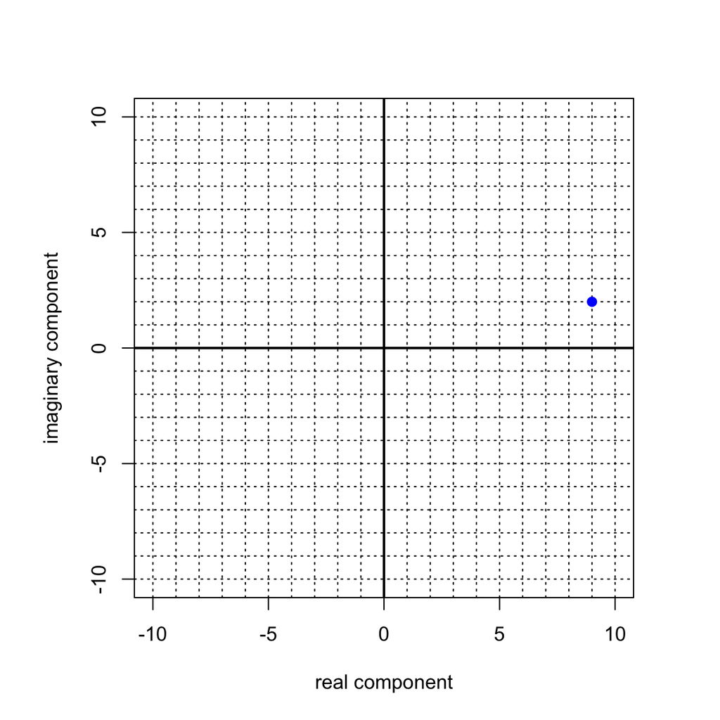

Please **write the value of $z$** (in rectangular form: $a+bi$).

*Type your answer precisely, with no spaces, using digits, "-", "+", and "i". If the real term is nonzero, put it first. If either component is zero, do not include that term. If both components are zero, type "0" without the quotes. Instead of writing "1i" or "-1i" just write "i" or "-i".*

The horizontal (real) component is 9. The vertical (imaginary) component is 2. So,
$$z = 9+2i$$

Let $z$ be a complex number with integer components. It is graphed on a [complex plane](https://en.wikipedia.org/wiki/Complex_plane) below.

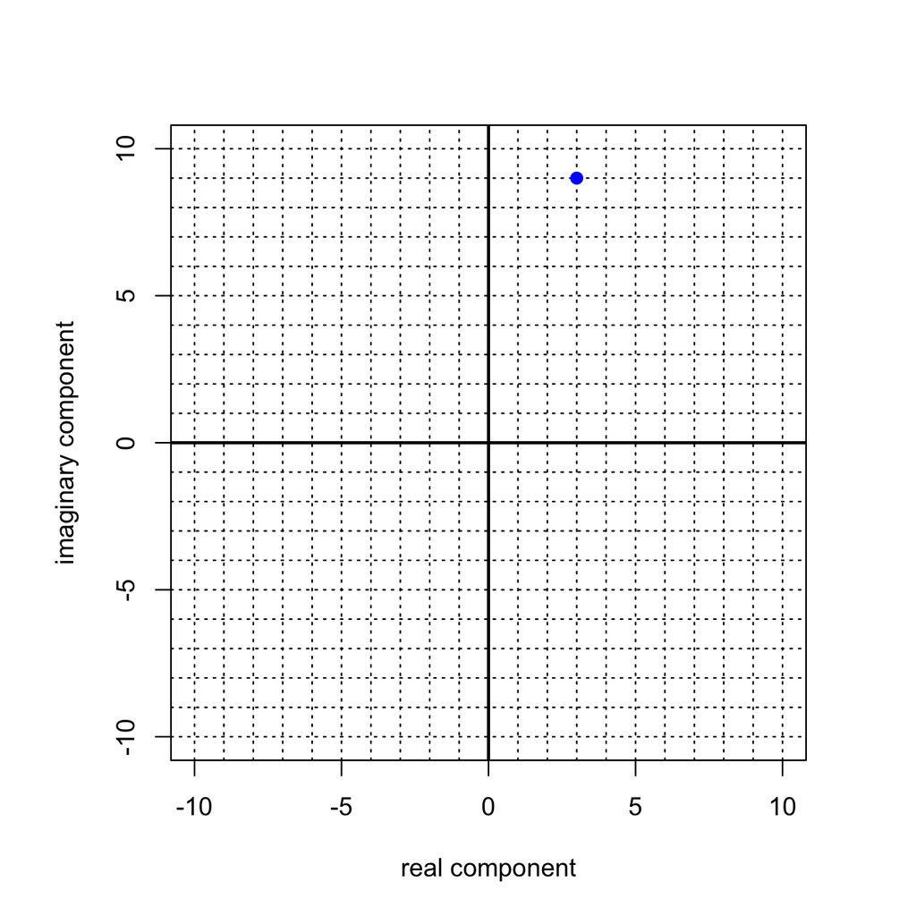

Please **write the value of $z$** (in rectangular form: $a+bi$).

*Type your answer precisely, with no spaces, using digits, "-", "+", and "i". If the real term is nonzero, put it first. If either component is zero, do not include that term. If both components are zero, type "0" without the quotes. Instead of writing "1i" or "-1i" just write "i" or "-i".*

The horizontal (real) component is 3. The vertical (imaginary) component is 9. So,
$$z = 3+9i$$

Let $z$ be a complex number with integer components. It is graphed on a [complex plane](https://en.wikipedia.org/wiki/Complex_plane) below.

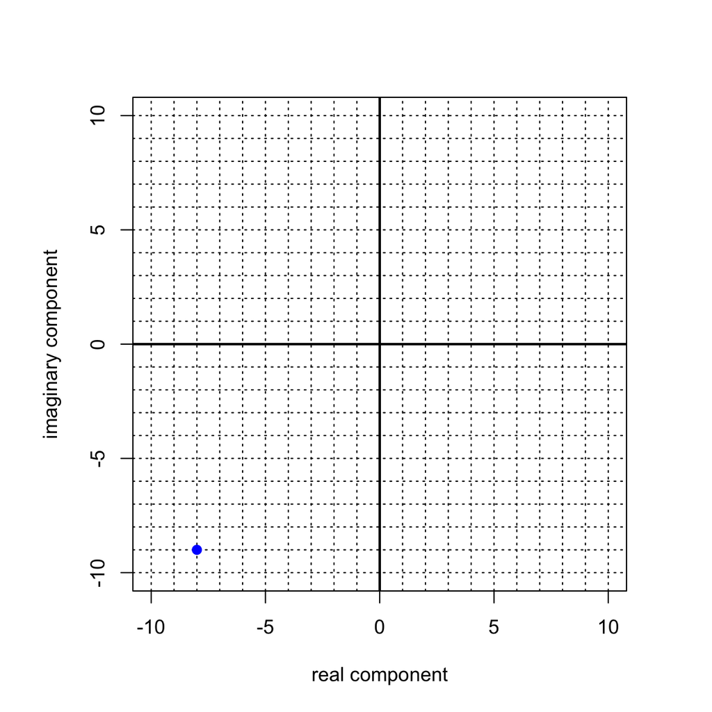

Please **write the value of $z$** (in rectangular form: $a+bi$).

*Type your answer precisely, with no spaces, using digits, "-", "+", and "i". If the real term is nonzero, put it first. If either component is zero, do not include that term. If both components are zero, type "0" without the quotes. Instead of writing "1i" or "-1i" just write "i" or "-i".*

The horizontal (real) component is -8. The vertical (imaginary) component is -9. So,
$$z = -8-9i$$

Let $z$ be a complex number with integer components. It is graphed on a [complex plane](https://en.wikipedia.org/wiki/Complex_plane) below.

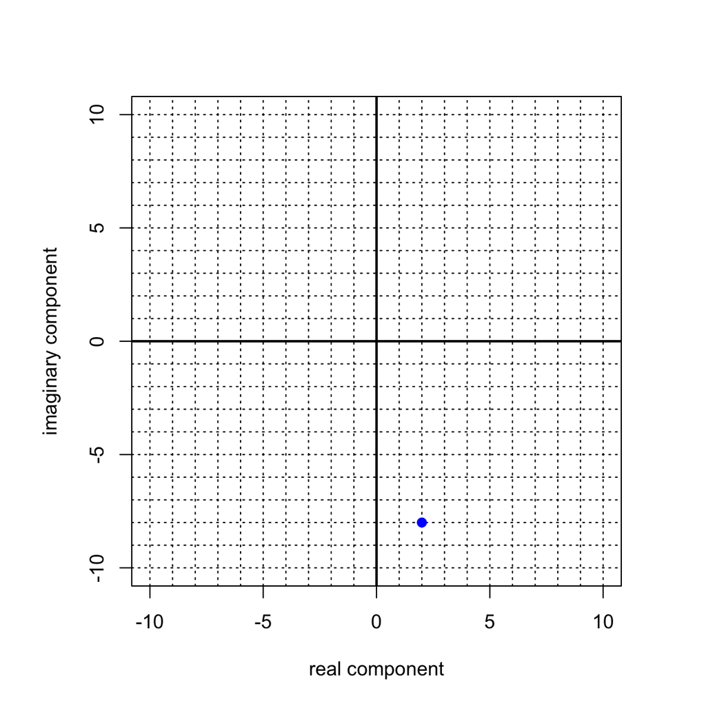

Please **write the value of $z$** (in rectangular form: $a+bi$).

*Type your answer precisely, with no spaces, using digits, "-", "+", and "i". If the real term is nonzero, put it first. If either component is zero, do not include that term. If both components are zero, type "0" without the quotes. Instead of writing "1i" or "-1i" just write "i" or "-i".*

The horizontal (real) component is 2. The vertical (imaginary) component is -8. So,
$$z = 2-8i$$

Let $z$ be a complex number with integer components. It is graphed on a [complex plane](https://en.wikipedia.org/wiki/Complex_plane) below.

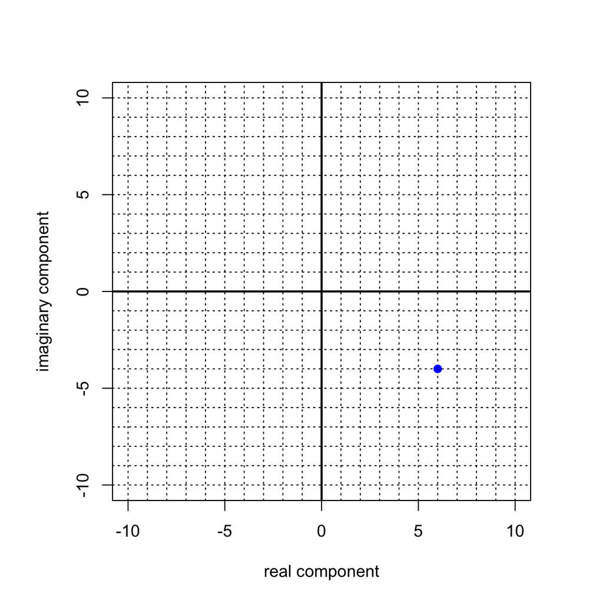

Please **write the value of $z$** (in rectangular form: $a+bi$).

*Type your answer precisely, with no spaces, using digits, "-", "+", and "i". If the real term is nonzero, put it first. If either component is zero, do not include that term. If both components are zero, type "0" without the quotes. Instead of writing "1i" or "-1i" just write "i" or "-i".*

The horizontal (real) component is 6. The vertical (imaginary) component is -4. So,
$$z = 6-4i$$

Let $z$ be a complex number with integer components. It is graphed on a [complex plane](https://en.wikipedia.org/wiki/Complex_plane) below.

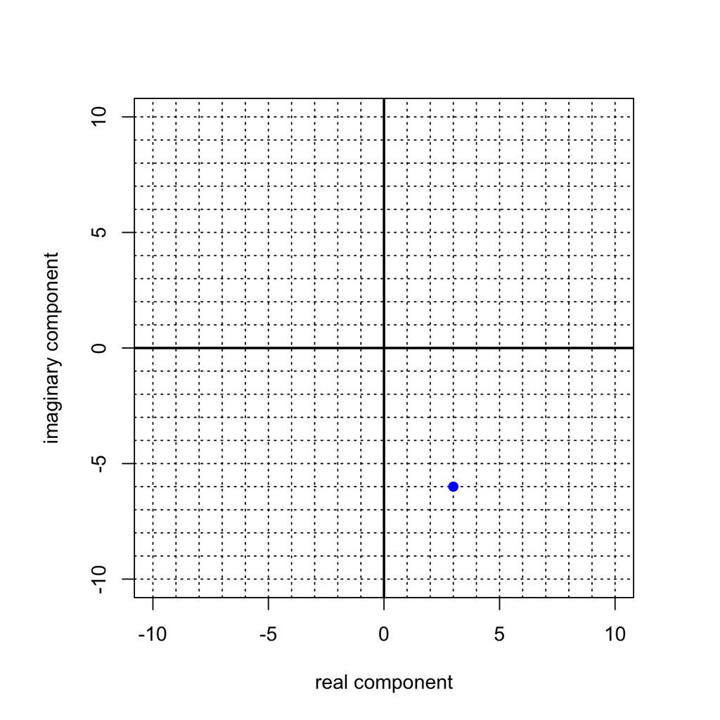

Please **write the value of $z$** (in rectangular form: $a+bi$).

*Type your answer precisely, with no spaces, using digits, "-", "+", and "i". If the real term is nonzero, put it first. If either component is zero, do not include that term. If both components are zero, type "0" without the quotes. Instead of writing "1i" or "-1i" just write "i" or "-i".*

The horizontal (real) component is 3. The vertical (imaginary) component is -6. So,
$$z = 3-6i$$

Let $z$ be a complex number with integer components. It is graphed on a [complex plane](https://en.wikipedia.org/wiki/Complex_plane) below.

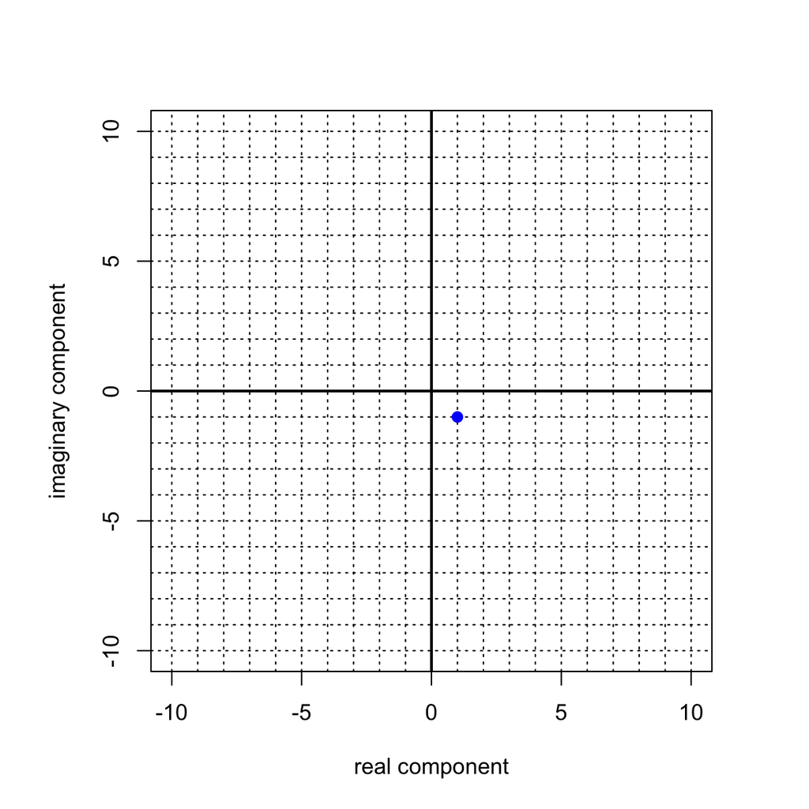

Please **write the value of $z$** (in rectangular form: $a+bi$).

*Type your answer precisely, with no spaces, using digits, "-", "+", and "i". If the real term is nonzero, put it first. If either component is zero, do not include that term. If both components are zero, type "0" without the quotes. Instead of writing "1i" or "-1i" just write "i" or "-i".*

The horizontal (real) component is 1. The vertical (imaginary) component is -1. So,
$$z = 1-i$$

Let $z$ be a complex number with integer components. It is graphed on a [complex plane](https://en.wikipedia.org/wiki/Complex_plane) below.

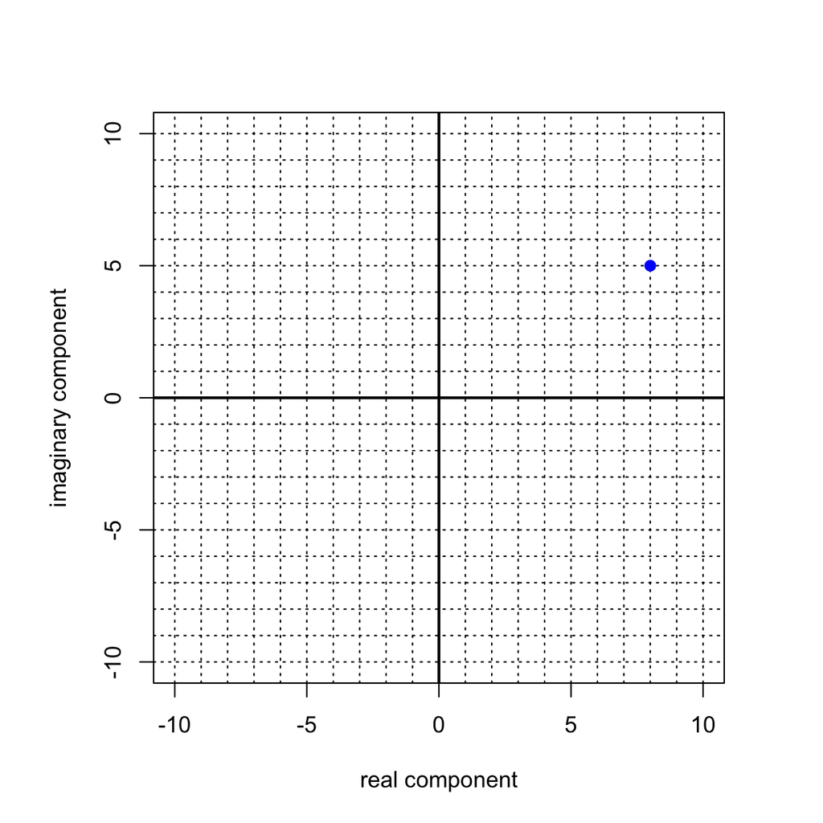

Please **write the value of $z$** (in rectangular form: $a+bi$).

*Type your answer precisely, with no spaces, using digits, "-", "+", and "i". If the real term is nonzero, put it first. If either component is zero, do not include that term. If both components are zero, type "0" without the quotes. Instead of writing "1i" or "-1i" just write "i" or "-i".*

The horizontal (real) component is 8. The vertical (imaginary) component is 5. So,
$$z = 8+5i$$

Let $z$ be a complex number with integer components. It is graphed on a [complex plane](https://en.wikipedia.org/wiki/Complex_plane) below.

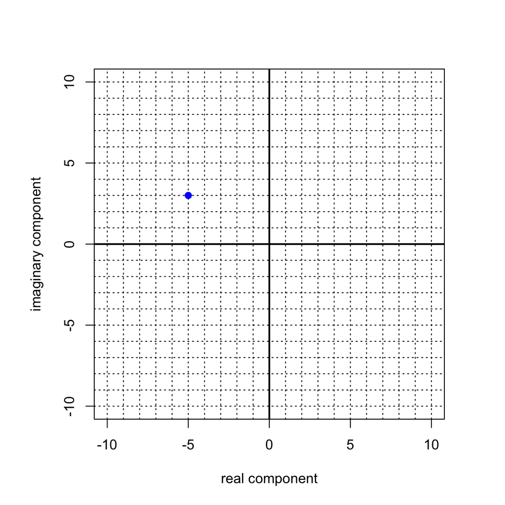

Please **write the value of $z$** (in rectangular form: $a+bi$).

*Type your answer precisely, with no spaces, using digits, "-", "+", and "i". If the real term is nonzero, put it first. If either component is zero, do not include that term. If both components are zero, type "0" without the quotes. Instead of writing "1i" or "-1i" just write "i" or "-i".*

The horizontal (real) component is -5. The vertical (imaginary) component is 3. So,
$$z = -5+3i$$

Let $z$ be a complex number with integer components. It is graphed on a [complex plane](https://en.wikipedia.org/wiki/Complex_plane) below.

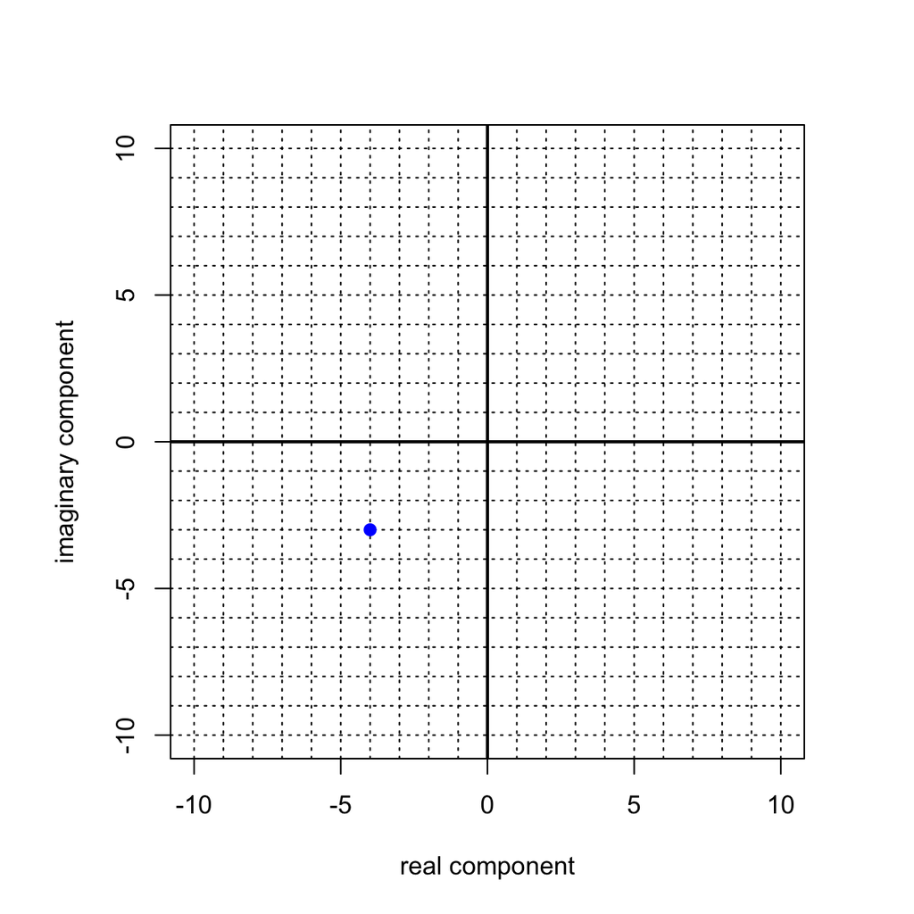

Please **write the value of $z$** (in rectangular form: $a+bi$).

*Type your answer precisely, with no spaces, using digits, "-", "+", and "i". If the real term is nonzero, put it first. If either component is zero, do not include that term. If both components are zero, type "0" without the quotes. Instead of writing "1i" or "-1i" just write "i" or "-i".*

The horizontal (real) component is -4. The vertical (imaginary) component is -3. So,
$$z = -4-3i$$

Let $z_1$ and $z_2$ be two [complex numbers](https://en.wikipedia.org/wiki/Complex_number).
$$z_1 = -9+3i$$
$$z_2 = 9-8i$$
Find the sum.
$$z_1+z_2 = ~?$$

*Type your answer precisely, with no spaces, using digits, "-", "+", and "i". If the real term is nonzero, put it first. If either component is zero, do not include that term. If both components are zero, type "0" without the quotes. Instead of writing "1i" or "-1i" just write "i" or "-i".*

For addition, just add the real components $(-9)+(9)=0$ and the imaginary components $(3)+(-8)=-5$. Then, type your answer:
$$-5i$$

Let $z_1$ and $z_2$ be two [complex numbers](https://en.wikipedia.org/wiki/Complex_number).
$$z_1 = -9-3i$$
$$z_2 = 7-3i$$
Find the sum.
$$z_1+z_2 = ~?$$

*Type your answer precisely, with no spaces, using digits, "-", "+", and "i". If the real term is nonzero, put it first. If either component is zero, do not include that term. If both components are zero, type "0" without the quotes. Instead of writing "1i" or "-1i" just write "i" or "-i".*

For addition, just add the real components $(-9)+(7)=-2$ and the imaginary components $(-3)+(-3)=-6$. Then, type your answer:
$$-2-6i$$

Let $z_1$ and $z_2$ be two [complex numbers](https://en.wikipedia.org/wiki/Complex_number).
$$z_1 = 6-9i$$
$$z_2 = 5-6i$$
Find the sum.
$$z_1+z_2 = ~?$$

*Type your answer precisely, with no spaces, using digits, "-", "+", and "i". If the real term is nonzero, put it first. If either component is zero, do not include that term. If both components are zero, type "0" without the quotes. Instead of writing "1i" or "-1i" just write "i" or "-i".*

For addition, just add the real components $(6)+(5)=11$ and the imaginary components $(-9)+(-6)=-15$. Then, type your answer:
$$11-15i$$

Let $z_1$ and $z_2$ be two [complex numbers](https://en.wikipedia.org/wiki/Complex_number).
$$z_1 = 1-7i$$
$$z_2 = -7+8i$$
Find the sum.
$$z_1+z_2 = ~?$$

*Type your answer precisely, with no spaces, using digits, "-", "+", and "i". If the real term is nonzero, put it first. If either component is zero, do not include that term. If both components are zero, type "0" without the quotes. Instead of writing "1i" or "-1i" just write "i" or "-i".*

For addition, just add the real components $(1)+(-7)=-6$ and the imaginary components $(-7)+(8)=1$. Then, type your answer:
$$-6+i$$

Let $z_1$ and $z_2$ be two [complex numbers](https://en.wikipedia.org/wiki/Complex_number).
$$z_1 = -8-6i$$
$$z_2 = 5+6i$$
Find the sum.
$$z_1+z_2 = ~?$$

*Type your answer precisely, with no spaces, using digits, "-", "+", and "i". If the real term is nonzero, put it first. If either component is zero, do not include that term. If both components are zero, type "0" without the quotes. Instead of writing "1i" or "-1i" just write "i" or "-i".*

For addition, just add the real components $(-8)+(5)=-3$ and the imaginary components $(-6)+(6)=0$. Then, type your answer:
$$-3$$

Let $z_1$ and $z_2$ be two [complex numbers](https://en.wikipedia.org/wiki/Complex_number).
$$z_1 = -2-7i$$
$$z_2 = -4+8i$$
Find the sum.
$$z_1+z_2 = ~?$$

*Type your answer precisely, with no spaces, using digits, "-", "+", and "i". If the real term is nonzero, put it first. If either component is zero, do not include that term. If both components are zero, type "0" without the quotes. Instead of writing "1i" or "-1i" just write "i" or "-i".*

For addition, just add the real components $(-2)+(-4)=-6$ and the imaginary components $(-7)+(8)=1$. Then, type your answer:
$$-6+i$$

Let $z_1$ and $z_2$ be two [complex numbers](https://en.wikipedia.org/wiki/Complex_number).
$$z_1 = 9-4i$$
$$z_2 = 9+i$$
Find the sum.
$$z_1+z_2 = ~?$$

*Type your answer precisely, with no spaces, using digits, "-", "+", and "i". If the real term is nonzero, put it first. If either component is zero, do not include that term. If both components are zero, type "0" without the quotes. Instead of writing "1i" or "-1i" just write "i" or "-i".*

For addition, just add the real components $(9)+(9)=18$ and the imaginary components $(-4)+(1)=-3$. Then, type your answer:
$$18-3i$$

Let $z_1$ and $z_2$ be two [complex numbers](https://en.wikipedia.org/wiki/Complex_number).
$$z_1 = 7-4i$$
$$z_2 = 4+8i$$
Find the sum.
$$z_1+z_2 = ~?$$

*Type your answer precisely, with no spaces, using digits, "-", "+", and "i". If the real term is nonzero, put it first. If either component is zero, do not include that term. If both components are zero, type "0" without the quotes. Instead of writing "1i" or "-1i" just write "i" or "-i".*

For addition, just add the real components $(7)+(4)=11$ and the imaginary components $(-4)+(8)=4$. Then, type your answer:
$$11+4i$$

Let $z_1$ and $z_2$ be two [complex numbers](https://en.wikipedia.org/wiki/Complex_number).
$$z_1 = -2-3i$$
$$z_2 = -8-3i$$
Find the sum.
$$z_1+z_2 = ~?$$

*Type your answer precisely, with no spaces, using digits, "-", "+", and "i". If the real term is nonzero, put it first. If either component is zero, do not include that term. If both components are zero, type "0" without the quotes. Instead of writing "1i" or "-1i" just write "i" or "-i".*

For addition, just add the real components $(-2)+(-8)=-10$ and the imaginary components $(-3)+(-3)=-6$. Then, type your answer:
$$-10-6i$$

Let $z_1$ and $z_2$ be two [complex numbers](https://en.wikipedia.org/wiki/Complex_number).
$$z_1 = 9+5i$$
$$z_2 = -8+7i$$
Find the sum.
$$z_1+z_2 = ~?$$

*Type your answer precisely, with no spaces, using digits, "-", "+", and "i". If the real term is nonzero, put it first. If either component is zero, do not include that term. If both components are zero, type "0" without the quotes. Instead of writing "1i" or "-1i" just write "i" or "-i".*

For addition, just add the real components $(9)+(-8)=1$ and the imaginary components $(5)+(7)=12$. Then, type your answer:
$$1+12i$$

Let $z_1$ and $z_2$ be two [complex numbers](https://en.wikipedia.org/wiki/Complex_number).
$$z_1 = -6+i$$
$$z_2 = 7-5i$$
Find the difference.
$$z_2-z_1 = ~?$$

*Type your answer precisely, with no spaces, using digits, "-", "+", and "i". If the real term is nonzero, put it first. If either component is zero, do not include that term. If both components are zero, type "0" without the quotes. Instead of writing "1i" or "-1i" just write "i" or "-i".*

For subtraction, just subtract the real components $(7)-(-6)=13$ and the imaginary components $(-5)-(1)=-6$. Then, type your answer:
$$13-6i$$

Let $z_1$ and $z_2$ be two [complex numbers](https://en.wikipedia.org/wiki/Complex_number).
$$z_1 = 2+6i$$
$$z_2 = -8+2i$$
Find the difference.
$$z_1-z_2 = ~?$$

*Type your answer precisely, with no spaces, using digits, "-", "+", and "i". If the real term is nonzero, put it first. If either component is zero, do not include that term. If both components are zero, type "0" without the quotes. Instead of writing "1i" or "-1i" just write "i" or "-i".*

For subtraction, just subtract the real components $(2)-(-8)=10$ and the imaginary components $(6)-(2)=4$. Then, type your answer:
$$10+4i$$

Let $z_1$ and $z_2$ be two [complex numbers](https://en.wikipedia.org/wiki/Complex_number).
$$z_1 = 1-4i$$
$$z_2 = -4+i$$
Find the difference.
$$z_1-z_2 = ~?$$

*Type your answer precisely, with no spaces, using digits, "-", "+", and "i". If the real term is nonzero, put it first. If either component is zero, do not include that term. If both components are zero, type "0" without the quotes. Instead of writing "1i" or "-1i" just write "i" or "-i".*

For subtraction, just subtract the real components $(1)-(-4)=5$ and the imaginary components $(-4)-(1)=-5$. Then, type your answer:
$$5-5i$$

Let $z_1$ and $z_2$ be two [complex numbers](https://en.wikipedia.org/wiki/Complex_number).
$$z_1 = -8-i$$
$$z_2 = 2+4i$$
Find the difference.
$$z_2-z_1 = ~?$$

*Type your answer precisely, with no spaces, using digits, "-", "+", and "i". If the real term is nonzero, put it first. If either component is zero, do not include that term. If both components are zero, type "0" without the quotes. Instead of writing "1i" or "-1i" just write "i" or "-i".*

For subtraction, just subtract the real components $(2)-(-8)=10$ and the imaginary components $(4)-(-1)=5$. Then, type your answer:
$$10+5i$$

Let $z_1$ and $z_2$ be two [complex numbers](https://en.wikipedia.org/wiki/Complex_number).
$$z_1 = -3+2i$$
$$z_2 = 9-7i$$
Find the difference.
$$z_2-z_1 = ~?$$

*Type your answer precisely, with no spaces, using digits, "-", "+", and "i". If the real term is nonzero, put it first. If either component is zero, do not include that term. If both components are zero, type "0" without the quotes. Instead of writing "1i" or "-1i" just write "i" or "-i".*

For subtraction, just subtract the real components $(9)-(-3)=12$ and the imaginary components $(-7)-(2)=-9$. Then, type your answer:
$$12-9i$$

Let $z_1$ and $z_2$ be two [complex numbers](https://en.wikipedia.org/wiki/Complex_number).
$$z_1 = -7+2i$$
$$z_2 = 5+6i$$
Find the difference.
$$z_2-z_1 = ~?$$

*Type your answer precisely, with no spaces, using digits, "-", "+", and "i". If the real term is nonzero, put it first. If either component is zero, do not include that term. If both components are zero, type "0" without the quotes. Instead of writing "1i" or "-1i" just write "i" or "-i".*

For subtraction, just subtract the real components $(5)-(-7)=12$ and the imaginary components $(6)-(2)=4$. Then, type your answer:
$$12+4i$$

Let $z_1$ and $z_2$ be two [complex numbers](https://en.wikipedia.org/wiki/Complex_number).
$$z_1 = -2-8i$$
$$z_2 = 1+7i$$
Find the difference.
$$z_2-z_1 = ~?$$

*Type your answer precisely, with no spaces, using digits, "-", "+", and "i". If the real term is nonzero, put it first. If either component is zero, do not include that term. If both components are zero, type "0" without the quotes. Instead of writing "1i" or "-1i" just write "i" or "-i".*

For subtraction, just subtract the real components $(1)-(-2)=3$ and the imaginary components $(7)-(-8)=15$. Then, type your answer:
$$3+15i$$

Let $z_1$ and $z_2$ be two [complex numbers](https://en.wikipedia.org/wiki/Complex_number).
$$z_1 = 8+9i$$
$$z_2 = 6-i$$
Find the difference.
$$z_1-z_2 = ~?$$

*Type your answer precisely, with no spaces, using digits, "-", "+", and "i". If the real term is nonzero, put it first. If either component is zero, do not include that term. If both components are zero, type "0" without the quotes. Instead of writing "1i" or "-1i" just write "i" or "-i".*

For subtraction, just subtract the real components $(8)-(6)=2$ and the imaginary components $(9)-(-1)=10$. Then, type your answer:
$$2+10i$$

Let $z_1$ and $z_2$ be two [complex numbers](https://en.wikipedia.org/wiki/Complex_number).
$$z_1 = 2+6i$$
$$z_2 = -8+8i$$
Find the difference.
$$z_1-z_2 = ~?$$

*Type your answer precisely, with no spaces, using digits, "-", "+", and "i". If the real term is nonzero, put it first. If either component is zero, do not include that term. If both components are zero, type "0" without the quotes. Instead of writing "1i" or "-1i" just write "i" or "-i".*

For subtraction, just subtract the real components $(2)-(-8)=10$ and the imaginary components $(6)-(8)=-2$. Then, type your answer:
$$10-2i$$

Let $z_1$ and $z_2$ be two [complex numbers](https://en.wikipedia.org/wiki/Complex_number).
$$z_1 = -3+7i$$
$$z_2 = 7-i$$
Find the difference.
$$z_2-z_1 = ~?$$

*Type your answer precisely, with no spaces, using digits, "-", "+", and "i". If the real term is nonzero, put it first. If either component is zero, do not include that term. If both components are zero, type "0" without the quotes. Instead of writing "1i" or "-1i" just write "i" or "-i".*

For subtraction, just subtract the real components $(7)-(-3)=10$ and the imaginary components $(-1)-(7)=-8$. Then, type your answer:
$$10-8i$$

Let $z_1$ and $z_2$ be two [complex numbers](https://en.wikipedia.org/wiki/Complex_number).
$$z_1 = 8-i$$
$$z_2 = -3+5i$$
Find the product.
$$z_1 \cdot z_2 = ~?$$

*Type your answer precisely, with no spaces, using digits, "-", "+", and "i". If the real term is nonzero, put it first. If either component is zero, do not include that term. If both components are zero, type "0" without the quotes. Instead of writing "1i" or "-1i" just write "i" or "-i".*

To multiply complex numbers, follow a procedure similar to [FOIL](https://en.wikipedia.org/wiki/FOIL_method), but remember $i^2=-1$.

$$(8-i)(-3+5i)$$

$$\Big((8)+(-1i)\Big)\Big((-3)+(5i)\Big)$$

$$(8)(-3)~~+~~(8)(5i)~~+~~(-1i)(-3)~~+~~(-1i)(5i)$$
$$-24~~+~~(40)i~~+~~(3)i
~~+~~(-5)i^2$$

You could also use a box to multiply.

| * | $8$ | $-1i$ |
| --- | --- | --- |
| $-3$ | $-24$ | $3i$ |
| $5i$ | $40i$ | $-5i^2$ |

$$-24~~+~~(40)i~~+~~(3)i
~~+~~(-5)i^2$$

Remember that $i^2=-1$.

$$-24~~+~~(40)i~~+~~(3)i~~+~~(5)$$

Let's group similar terms. We put the real terms to the left and the imaginary terms to the right.

$$-24~~+~~(5)~~+~~(40)i~~+~~(3)i$$
Combine the real terms and combine the imaginary terms.

$$-19+43i$$

Let $z_1$ and $z_2$ be two [complex numbers](https://en.wikipedia.org/wiki/Complex_number).
$$z_1 = 2-9i$$
$$z_2 = -3-9i$$
Find the product.
$$z_1 \cdot z_2 = ~?$$

*Type your answer precisely, with no spaces, using digits, "-", "+", and "i". If the real term is nonzero, put it first. If either component is zero, do not include that term. If both components are zero, type "0" without the quotes. Instead of writing "1i" or "-1i" just write "i" or "-i".*

To multiply complex numbers, follow a procedure similar to [FOIL](https://en.wikipedia.org/wiki/FOIL_method), but remember $i^2=-1$.

$$(2-9i)(-3-9i)$$

$$\Big((2)+(-9i)\Big)\Big((-3)+(-9i)\Big)$$

$$(2)(-3)~~+~~(2)(-9i)~~+~~(-9i)(-3)~~+~~(-9i)(-9i)$$
$$-6~~+~~(-18)i~~+~~(27)i
~~+~~(81)i^2$$

You could also use a box to multiply.

| * | $2$ | $-9i$ |
| --- | --- | --- |
| $-3$ | $-6$ | $27i$ |
| $-9i$ | $-18i$ | $81i^2$ |

$$-6~~+~~(-18)i~~+~~(27)i
~~+~~(81)i^2$$

Remember that $i^2=-1$.

$$-6~~+~~(-18)i~~+~~(27)i~~+~~(-81)$$

Let's group similar terms. We put the real terms to the left and the imaginary terms to the right.

$$-6~~+~~(-81)~~+~~(-18)i~~+~~(27)i$$
Combine the real terms and combine the imaginary terms.

$$-87+9i$$

Let $z_1$ and $z_2$ be two [complex numbers](https://en.wikipedia.org/wiki/Complex_number).
$$z_1 = 1+5i$$
$$z_2 = 9-6i$$
Find the product.
$$z_1 \cdot z_2 = ~?$$

*Type your answer precisely, with no spaces, using digits, "-", "+", and "i". If the real term is nonzero, put it first. If either component is zero, do not include that term. If both components are zero, type "0" without the quotes. Instead of writing "1i" or "-1i" just write "i" or "-i".*

To multiply complex numbers, follow a procedure similar to [FOIL](https://en.wikipedia.org/wiki/FOIL_method), but remember $i^2=-1$.

$$(1+5i)(9-6i)$$

$$\Big((1)+(5i)\Big)\Big((9)+(-6i)\Big)$$

$$(1)(9)~~+~~(1)(-6i)~~+~~(5i)(9)~~+~~(5i)(-6i)$$
$$9~~+~~(-6)i~~+~~(45)i
~~+~~(-30)i^2$$

You could also use a box to multiply.

| * | $1$ | $5i$ |
| --- | --- | --- |
| $9$ | $9$ | $45i$ |
| $-6i$ | $-6i$ | $-30i^2$ |

$$9~~+~~(-6)i~~+~~(45)i
~~+~~(-30)i^2$$

Remember that $i^2=-1$.

$$9~~+~~(-6)i~~+~~(45)i~~+~~(30)$$

Let's group similar terms. We put the real terms to the left and the imaginary terms to the right.

$$9~~+~~(30)~~+~~(-6)i~~+~~(45)i$$
Combine the real terms and combine the imaginary terms.

$$39+39i$$

Let $z_1$ and $z_2$ be two [complex numbers](https://en.wikipedia.org/wiki/Complex_number).
$$z_1 = -3-9i$$
$$z_2 = 6+3i$$
Find the product.
$$z_1 \cdot z_2 = ~?$$

*Type your answer precisely, with no spaces, using digits, "-", "+", and "i". If the real term is nonzero, put it first. If either component is zero, do not include that term. If both components are zero, type "0" without the quotes. Instead of writing "1i" or "-1i" just write "i" or "-i".*

To multiply complex numbers, follow a procedure similar to [FOIL](https://en.wikipedia.org/wiki/FOIL_method), but remember $i^2=-1$.

$$(-3-9i)(6+3i)$$

$$\Big((-3)+(-9i)\Big)\Big((6)+(3i)\Big)$$

$$(-3)(6)~~+~~(-3)(3i)~~+~~(-9i)(6)~~+~~(-9i)(3i)$$
$$-18~~+~~(-9)i~~+~~(-54)i
~~+~~(-27)i^2$$

You could also use a box to multiply.

| * | $-3$ | $-9i$ |
| --- | --- | --- |
| $6$ | $-18$ | $-54i$ |
| $3i$ | $-9i$ | $-27i^2$ |

$$-18~~+~~(-9)i~~+~~(-54)i
~~+~~(-27)i^2$$

Remember that $i^2=-1$.

$$-18~~+~~(-9)i~~+~~(-54)i~~+~~(27)$$

Let's group similar terms. We put the real terms to the left and the imaginary terms to the right.

$$-18~~+~~(27)~~+~~(-9)i~~+~~(-54)i$$
Combine the real terms and combine the imaginary terms.

$$9-63i$$

Let $z_1$ and $z_2$ be two [complex numbers](https://en.wikipedia.org/wiki/Complex_number).
$$z_1 = -7+2i$$
$$z_2 = 8+i$$
Find the product.
$$z_1 \cdot z_2 = ~?$$

*Type your answer precisely, with no spaces, using digits, "-", "+", and "i". If the real term is nonzero, put it first. If either component is zero, do not include that term. If both components are zero, type "0" without the quotes. Instead of writing "1i" or "-1i" just write "i" or "-i".*

To multiply complex numbers, follow a procedure similar to [FOIL](https://en.wikipedia.org/wiki/FOIL_method), but remember $i^2=-1$.

$$(-7+2i)(8+i)$$

$$\Big((-7)+(2i)\Big)\Big((8)+(1i)\Big)$$

$$(-7)(8)~~+~~(-7)(1i)~~+~~(2i)(8)~~+~~(2i)(1i)$$
$$-56~~+~~(-7)i~~+~~(16)i
~~+~~(2)i^2$$

You could also use a box to multiply.

| * | $-7$ | $2i$ |
| --- | --- | --- |
| $8$ | $-56$ | $16i$ |
| $1i$ | $-7i$ | $2i^2$ |

$$-56~~+~~(-7)i~~+~~(16)i
~~+~~(2)i^2$$

Remember that $i^2=-1$.

$$-56~~+~~(-7)i~~+~~(16)i~~+~~(-2)$$

Let's group similar terms. We put the real terms to the left and the imaginary terms to the right.

$$-56~~+~~(-2)~~+~~(-7)i~~+~~(16)i$$
Combine the real terms and combine the imaginary terms.

$$-58+9i$$

Let $z_1$ and $z_2$ be two [complex numbers](https://en.wikipedia.org/wiki/Complex_number).
$$z_1 = -5+3i$$
$$z_2 = -1+5i$$
Find the product.
$$z_1 \cdot z_2 = ~?$$

*Type your answer precisely, with no spaces, using digits, "-", "+", and "i". If the real term is nonzero, put it first. If either component is zero, do not include that term. If both components are zero, type "0" without the quotes. Instead of writing "1i" or "-1i" just write "i" or "-i".*

To multiply complex numbers, follow a procedure similar to [FOIL](https://en.wikipedia.org/wiki/FOIL_method), but remember $i^2=-1$.

$$(-5+3i)(-1+5i)$$

$$\Big((-5)+(3i)\Big)\Big((-1)+(5i)\Big)$$

$$(-5)(-1)~~+~~(-5)(5i)~~+~~(3i)(-1)~~+~~(3i)(5i)$$
$$5~~+~~(-25)i~~+~~(-3)i
~~+~~(15)i^2$$

You could also use a box to multiply.

| * | $-5$ | $3i$ |
| --- | --- | --- |
| $-1$ | $5$ | $-3i$ |
| $5i$ | $-25i$ | $15i^2$ |

$$5~~+~~(-25)i~~+~~(-3)i
~~+~~(15)i^2$$

Remember that $i^2=-1$.

$$5~~+~~(-25)i~~+~~(-3)i~~+~~(-15)$$

Let's group similar terms. We put the real terms to the left and the imaginary terms to the right.

$$5~~+~~(-15)~~+~~(-25)i~~+~~(-3)i$$
Combine the real terms and combine the imaginary terms.

$$-10-28i$$

Let $z_1$ and $z_2$ be two [complex numbers](https://en.wikipedia.org/wiki/Complex_number).
$$z_1 = 5-8i$$
$$z_2 = -9+2i$$
Find the product.
$$z_1 \cdot z_2 = ~?$$

*Type your answer precisely, with no spaces, using digits, "-", "+", and "i". If the real term is nonzero, put it first. If either component is zero, do not include that term. If both components are zero, type "0" without the quotes. Instead of writing "1i" or "-1i" just write "i" or "-i".*

To multiply complex numbers, follow a procedure similar to [FOIL](https://en.wikipedia.org/wiki/FOIL_method), but remember $i^2=-1$.

$$(5-8i)(-9+2i)$$

$$\Big((5)+(-8i)\Big)\Big((-9)+(2i)\Big)$$

$$(5)(-9)~~+~~(5)(2i)~~+~~(-8i)(-9)~~+~~(-8i)(2i)$$
$$-45~~+~~(10)i~~+~~(72)i
~~+~~(-16)i^2$$

You could also use a box to multiply.

| * | $5$ | $-8i$ |
| --- | --- | --- |
| $-9$ | $-45$ | $72i$ |
| $2i$ | $10i$ | $-16i^2$ |

$$-45~~+~~(10)i~~+~~(72)i
~~+~~(-16)i^2$$

Remember that $i^2=-1$.

$$-45~~+~~(10)i~~+~~(72)i~~+~~(16)$$

Let's group similar terms. We put the real terms to the left and the imaginary terms to the right.

$$-45~~+~~(16)~~+~~(10)i~~+~~(72)i$$
Combine the real terms and combine the imaginary terms.

$$-29+82i$$

Let $z_1$ and $z_2$ be two [complex numbers](https://en.wikipedia.org/wiki/Complex_number).
$$z_1 = 5-4i$$
$$z_2 = -8-9i$$
Find the product.
$$z_1 \cdot z_2 = ~?$$

*Type your answer precisely, with no spaces, using digits, "-", "+", and "i". If the real term is nonzero, put it first. If either component is zero, do not include that term. If both components are zero, type "0" without the quotes. Instead of writing "1i" or "-1i" just write "i" or "-i".*

To multiply complex numbers, follow a procedure similar to [FOIL](https://en.wikipedia.org/wiki/FOIL_method), but remember $i^2=-1$.

$$(5-4i)(-8-9i)$$

$$\Big((5)+(-4i)\Big)\Big((-8)+(-9i)\Big)$$

$$(5)(-8)~~+~~(5)(-9i)~~+~~(-4i)(-8)~~+~~(-4i)(-9i)$$
$$-40~~+~~(-45)i~~+~~(32)i
~~+~~(36)i^2$$

You could also use a box to multiply.

| * | $5$ | $-4i$ |
| --- | --- | --- |
| $-8$ | $-40$ | $32i$ |
| $-9i$ | $-45i$ | $36i^2$ |

$$-40~~+~~(-45)i~~+~~(32)i
~~+~~(36)i^2$$

Remember that $i^2=-1$.

$$-40~~+~~(-45)i~~+~~(32)i~~+~~(-36)$$

Let's group similar terms. We put the real terms to the left and the imaginary terms to the right.

$$-40~~+~~(-36)~~+~~(-45)i~~+~~(32)i$$
Combine the real terms and combine the imaginary terms.

$$-76-13i$$

Let $z_1$ and $z_2$ be two [complex numbers](https://en.wikipedia.org/wiki/Complex_number).
$$z_1 = -3-i$$
$$z_2 = 5-5i$$
Find the product.
$$z_1 \cdot z_2 = ~?$$

*Type your answer precisely, with no spaces, using digits, "-", "+", and "i". If the real term is nonzero, put it first. If either component is zero, do not include that term. If both components are zero, type "0" without the quotes. Instead of writing "1i" or "-1i" just write "i" or "-i".*

To multiply complex numbers, follow a procedure similar to [FOIL](https://en.wikipedia.org/wiki/FOIL_method), but remember $i^2=-1$.

$$(-3-i)(5-5i)$$

$$\Big((-3)+(-1i)\Big)\Big((5)+(-5i)\Big)$$

$$(-3)(5)~~+~~(-3)(-5i)~~+~~(-1i)(5)~~+~~(-1i)(-5i)$$
$$-15~~+~~(15)i~~+~~(-5)i
~~+~~(5)i^2$$

You could also use a box to multiply.

| * | $-3$ | $-1i$ |
| --- | --- | --- |
| $5$ | $-15$ | $-5i$ |
| $-5i$ | $15i$ | $5i^2$ |

$$-15~~+~~(15)i~~+~~(-5)i
~~+~~(5)i^2$$

Remember that $i^2=-1$.

$$-15~~+~~(15)i~~+~~(-5)i~~+~~(-5)$$

Let's group similar terms. We put the real terms to the left and the imaginary terms to the right.

$$-15~~+~~(-5)~~+~~(15)i~~+~~(-5)i$$
Combine the real terms and combine the imaginary terms.

$$-20+10i$$

Let $z_1$ and $z_2$ be two [complex numbers](https://en.wikipedia.org/wiki/Complex_number).
$$z_1 = -5-9i$$
$$z_2 = 8-i$$
Find the product.
$$z_1 \cdot z_2 = ~?$$

*Type your answer precisely, with no spaces, using digits, "-", "+", and "i". If the real term is nonzero, put it first. If either component is zero, do not include that term. If both components are zero, type "0" without the quotes. Instead of writing "1i" or "-1i" just write "i" or "-i".*

To multiply complex numbers, follow a procedure similar to [FOIL](https://en.wikipedia.org/wiki/FOIL_method), but remember $i^2=-1$.

$$(-5-9i)(8-i)$$

$$\Big((-5)+(-9i)\Big)\Big((8)+(-1i)\Big)$$

$$(-5)(8)~~+~~(-5)(-1i)~~+~~(-9i)(8)~~+~~(-9i)(-1i)$$
$$-40~~+~~(5)i~~+~~(-72)i
~~+~~(9)i^2$$

You could also use a box to multiply.

| * | $-5$ | $-9i$ |
| --- | --- | --- |
| $8$ | $-40$ | $-72i$ |
| $-1i$ | $5i$ | $9i^2$ |

$$-40~~+~~(5)i~~+~~(-72)i
~~+~~(9)i^2$$

Remember that $i^2=-1$.

$$-40~~+~~(5)i~~+~~(-72)i~~+~~(-9)$$

Let's group similar terms. We put the real terms to the left and the imaginary terms to the right.

$$-40~~+~~(-9)~~+~~(5)i~~+~~(-72)i$$
Combine the real terms and combine the imaginary terms.

$$-49-67i$$